# Homework 6 Programming Task

### IST 5520, 2022 Fall

**Instruction:**

Complete the following tasks (1 point for each task and question, 12 points in total). You can add additional lines if necessary.

# Task: Summarize and Visualize Data (12 points)

## (1) Read in dataset

The data file “UniversalBank.csv” contains a dataset of 5000 customers of the Universal Bank.

Below is the description of columns in the dataset.

- Id: Customer ID
- Age: Customer’s age in completed years
- Experience: #years of professional experience
- Income: Annual income of the customer (1000 dollars)
- ZIPCode: Home Address ZIP code.
- Family: Family size of the customer
- CCAvg: Avg. spending on credit cards per month (1000 dollors)
- Education: Education Level. 1: Undergrad; 2: Graduate; 3: Advanced/Professional
- Mortgage: Value of house mortgage if any. (1000 dollars)
- Personal_Loan: Did this customer accept the personal loan offered in the last campaign?
- Securities_Account: Does the customer have a securities account with the bank?
- CD_Account: Does the customer have a certificate of deposit (CD) account with the bank?
- Online: Does the customer use internet banking facilities?
- CreditCard: Does the customer use a credit card issued by UniversalBank?

```python
import pandas as pd
df = pd.read_csv('../Data/UniversalBank.csv')
df.head()
```

|  | Id | Age | Experience | Income | ZIP_Code | Family | CCAvg | Education | Mortgage | Personal_Loan | Securities_Account | CD_Account | Online | CreditCard |
| --- | --- | --- | --- | --- | --- | --- | --- | --- | --- | --- | --- | --- | --- | --- |
| 0 | 1 | 25 | 1 | 49 | 91107 | 4 | 1.6 | 1 | 0 | 0 | 1 | 0 | 0 | 0 |
| 1 | 2 | 45 | 19 | 34 | 90089 | 3 | 1.5 | 1 | 0 | 0 | 1 | 0 | 0 | 0 |
| 2 | 3 | 39 | 15 | 11 | 94720 | 1 | 1.0 | 1 | 0 | 0 | 0 | 0 | 0 | 0 |
| 3 | 4 | 35 | 9 | 100 | 94112 | 1 | 2.7 | 2 | 0 | 0 | 0 | 0 | 0 | 0 |
| 4 | 5 | 35 | 8 | 45 | 91330 | 4 | 1.0 | 2 | 0 | 0 | 0 | 0 | 0 | 1 |

## (2) Print the number of observations and the number of variables in the dataset.

Use the following format:

"Number of observations = xxx"

"Number of variables = xxx"

```python
print('Number of observations =', df.shape[0])
```

```
Number of observations = 5000
```

```python
print('Number of variables =', df.shape[1])
```

```
Number of variables = 14
```

## (3) Create a contingency table (two-way frequency table) of 'Family' and 'Education', showing subtotals (margins)

```python
pd.crosstab(df['Family'], df['Education'], margins=True)
```

| Education Family | 1 | 2 | 3 | All |
| --- | --- | --- | --- | --- |
| 1 | 678 | 326 | 468 | 1472 |
| 2 | 657 | 265 | 374 | 1296 |
| 3 | 349 | 383 | 278 | 1010 |
| 4 | 412 | 429 | 381 | 1222 |
| All | 2096 | 1403 | 1501 | 5000 |

**Question 1**: What is the value in the cell where Family=3 and Education=1? Type your answer below (1 point)

Your answer: 349

Interpret the meaning of this value below (1 point).

Your interpretation:

There are 349 customers in the dataset who have 3 family members and an undergrad degree.

## (4) Draw a scatter plot of 'Income' and 'CCAvg'.

Use Income as x variable, CCAvg as y variable.

Specify the labels of x-axis and y-axis by using easy-to-understand language.

```python
import matplotlib.pyplot as plt
import seaborn as sns
```

```python
# Enable inline plotting in notebook
%matplotlib inline
```

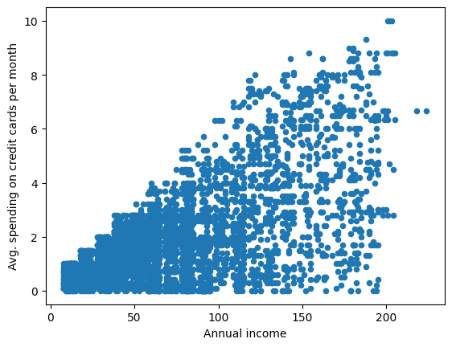

```python
df.plot(kind='scatter',x='Income',y='CCAvg')
plt.xlabel('Annual income')
plt.ylabel('Avg. spending on credit cards per month')
plt.show()
```

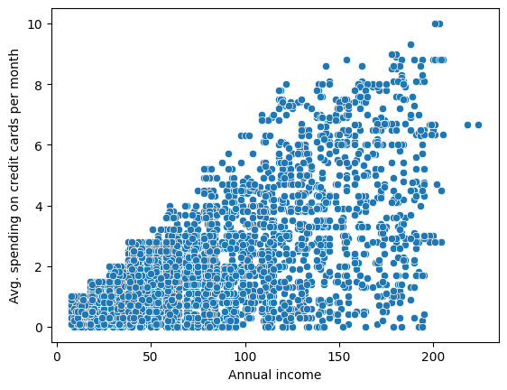

```python
# Alternative approach using searborn
sns.scatterplot(x='Income', y='CCAvg', data=df)
plt.xlabel('Annual income')
plt.ylabel('Avg. spending on credit cards per month')
plt.show()
```

**Question 2**: Based on the scatter plot, what is the relationship between anual income and average spending on credit cards? Type your answer below.(2 points)

Your answer:

These two variables seem positively correlated.

## (5) Draw a boxplot of Income grouped by Personal_Loan.

Draw a boxplot of income for customers who accepted the personal loan and another boxplot for customers who did not accept the personal loan. Show all the two boxplots in a single graph.

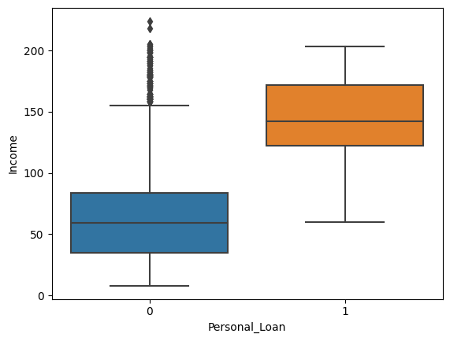

```python
sns.boxplot(x='Personal_Loan', y='Income', data=df)
```

**Question 3**: Based on the box plot, which group of customers contains outliers of income? What is the relationship between a customer's income and whether the customer accepted the personal loan? Type all your answers below.(2 points)

Your answer:

There are outliers of income in the group of customers who did not accept personal loan. Customers who accepted personal load tend to have higher level of income, although there are some exceptional customers who did not accept personal loan but had very high level income (those outliers in the above boxplot).

## (6) Detect potential outliers in Income

Draw a boxplot of Income for all customers. Show all observations in the dataset that contain outliers in the Income variable.

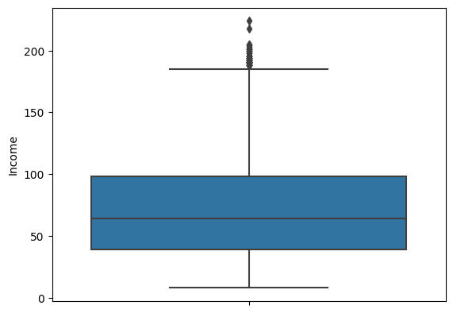

```python
sns.boxplot(y='Income', data=df)
```

```python
# Calculate the first quantile
first_quantile = df['Income'].quantile(0.25)

# Calculate the first quantile
third_quantile = df['Income'].quantile(0.75)

# Calculate the interquantile range (IQR)
IQR = third_quantile - first_quantile
```

```python
# Outliers below the boxplot
df[df['Income']<first_quantile-1.5*IQR]
```

|  | Id | Age | Experience | Income | ZIP_Code | Family | CCAvg | Education | Mortgage | Personal_Loan | Securities_Account | CD_Account | Online | CreditCard |
| --- | --- | --- | --- | --- | --- | --- | --- | --- | --- | --- | --- | --- | --- | --- |

```python
# Outliers below the boxplot
df[df['Income']>third_quantile+1.5*IQR]
```

|  | Id | Age | Experience | Income | ZIP_Code | Family | CCAvg | Education | Mortgage | Personal_Loan | Securities_Account | CD_Account | Online | CreditCard |
| --- | --- | --- | --- | --- | --- | --- | --- | --- | --- | --- | --- | --- | --- | --- |
| 18 | 19 | 46 | 21 | 193 | 91604 | 2 | 8.10 | 3 | 0 | 1 | 0 | 0 | 0 | 0 |
| 47 | 48 | 37 | 12 | 194 | 91380 | 4 | 0.20 | 3 | 211 | 1 | 1 | 1 | 1 | 1 |
| 53 | 54 | 50 | 26 | 190 | 90245 | 3 | 2.10 | 3 | 240 | 1 | 0 | 0 | 1 | 0 |
| 59 | 60 | 31 | 5 | 188 | 91320 | 2 | 4.50 | 1 | 455 | 0 | 0 | 0 | 0 | 0 |
| 303 | 304 | 49 | 25 | 195 | 95605 | 4 | 3.00 | 1 | 617 | 1 | 0 | 0 | 0 | 0 |
| ... | ... | ... | ... | ... | ... | ... | ... | ... | ... | ... | ... | ... | ... | ... |
| 4659 | 4660 | 28 | 4 | 199 | 92121 | 1 | 6.33 | 1 | 0 | 0 | 0 | 0 | 0 | 0 |
| 4670 | 4671 | 52 | 26 | 194 | 94305 | 1 | 1.70 | 1 | 0 | 0 | 0 | 0 | 1 | 0 |
| 4895 | 4896 | 45 | 20 | 201 | 92120 | 2 | 2.80 | 1 | 0 | 0 | 0 | 0 | 1 | 1 |
| 4981 | 4982 | 34 | 9 | 195 | 90266 | 2 | 3.00 | 1 | 122 | 0 | 0 | 0 | 1 | 0 |
| 4993 | 4994 | 45 | 21 | 218 | 91801 | 2 | 6.67 | 1 | 0 | 0 | 0 | 0 | 1 | 0 |

96 rows × 14 columns

**Question 4**: How many outliers have you detected? Type your answer below.(2 points)

Print your answer below. Use the format 'The number of outliers detected = xx'.

```python
outlier_num = df[df['Income']<first_quantile-1.5*IQR].shape[0] + df[df['Income']>third_quantile+1.5*IQR].shape[0]

print('The number of outliers detected =',outlier_num)
```

```
The number of outliers detected = 96
```

## (7) Draw a bar chart of CCAvg for all family sizes.

Show a bar for each family size.

Show standard errors on the bars.

```python
# Calculate mean ccavg per family
mean_aacvg_by_family = df[['CCAvg','Family']].groupby('Family').mean()
mean_aacvg_by_family
```

| Family | CCAvg |
| --- | --- |
| 1 | 2.065591 |
| 2 | 2.235748 |
| 3 | 1.700327 |
| 4 | 1.664714 |

```python
# Calculate standard errors
std = df[['CCAvg','Family']].groupby('Family').std()
std
```

| Family | CCAvg |
| --- | --- |
| 1 | 1.834348 |
| 2 | 2.081365 |
| 3 | 1.466049 |
| 4 | 1.358377 |

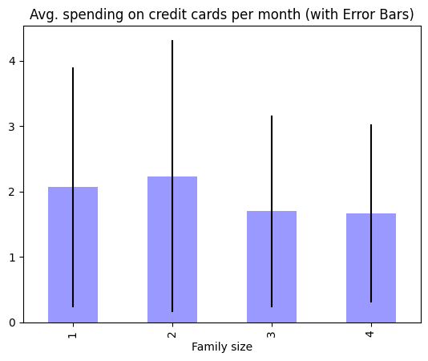

```python
mean_aacvg_by_family.plot(kind='bar', color='b', yerr = std, alpha=0.4,align='center',legend = False)
plt.title('Avg. spending on credit cards per month (with Error Bars)')
plt.xticks(rotation=90)
plt.xlabel('Family size')
plt.show()
```

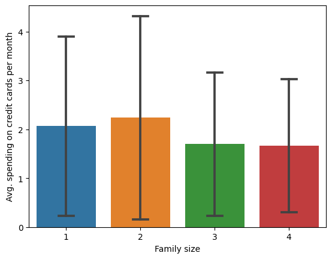

```python
# Alternative approach using searborn
sns.barplot(x="Family", y="CCAvg", ci='sd', capsize=.2, data=df)
plt.ylabel('Avg. spending on credit cards per month')
plt.xlabel('Family size')
plt.show()
```

**Question 5**: Based on the above bar plot, which family has the highest average spending on credit cards per month? Which family size has the greatest variation in the average spending? Type your answers below.(2 points)

Your answer:

Family size = 2 has the both the highest average spending and the highest variation in monthly spending on credit cards.